# ***Electric Vehicle Market Size Analysis***

**Context and Content:** Market Size Analysis is the process of estimating the potential sales for a product or service within a particular market segment. In the context of electric vehicles (EV's), it involves assessing the total volume of EV registrations to understand the growth of the market, forecast future trends, and help stakeholders make informed decisions regarding production, infrastructure development, and policy-making.

Dataset contains the following columns, each representing following aspects of the electric vehicle (EV) population in the United States.

SL.No. **Column Name--** Description

1. **VIN (1-10) :** Partial Vehicle Identification Number.

2. **County :** The county in which the vehicle is registered.

3. **City :** The city in which the vehicle is registered.

4. **State :** The state in which the vehicle is registered. It appears that this dataset may be focused on Washington (WA) state.

5. **Postal Code :** The postal code where the vehicle is registered.

6. **Model Year :** The year of the vehicle model.

7. **Make :** The manufacturer of the vehicle.

8. **Model :** The model of the vehicle.

9. **Electric Vehicle Type :** The type of electric vehicle, e.g., Battery Electric Vehicle (BEV).

10. **Clean Alternative Fuel Vehicle (CAFV) Eligibility :** Eligibility status for clean alternative fuel vehicle programs.

11. **Electric Range :** The maximum range of the vehicle on a single charge (in miles).

12. **Base MSRP :** The Manufacturer’s Suggested Retail Price.

13. **Legislative District :** The legislative district where the vehicle is registered.

14. **DOL Vehicle ID :** Department of Licensing Vehicle Identification.

15. **Vehicle Location :** Geographic coordinates of the vehicle location.

16. **Electric Utility :** The electric utility service provider for the vehicle’s location.

17. **2020 Census Tract :** The census tract for the vehicle’s location.

**Objective:**

The primary objective of this analysis is to leverage historical EV registration data to understand the current market penetration of EVs, predict future market growth, and identify key trends and factors driving market expansion. The specific goals include:

● Assess the historical growth trend of EV registrations.

● Forecast future EV registrations based on historical trends.

● Analyze the distribution of EV registrations across different models, makes, and geographical regions.

● Estimate the market size and growth potential of the EV market for upcoming years.

● Provide insights to support stakeholders in decision-making processes related to production, infrastructure planning, and policy formulation.

# ANALYSIS:-

### Import required Python libraries .

```python
import numpy as np
import pandas as pd
import matplotlib.pyplot as plt
import seaborn as sns
sns.set_style('whitegrid')
```

### Read the dataset and retrieve top 5 and bottom 5 records.

```python
ev_data = pd.read_csv(r"D:\projects\Pthon\EV market size\Electric_Vehicle_Population_Data.csv")
ev_data
```

|  | VIN (1-10) | County | City | State | Postal Code | Model Year | Make | Model | Electric Vehicle Type | Clean Alternative Fuel Vehicle (CAFV) Eligibility | Electric Range | Base MSRP | Legislative District | DOL Vehicle ID | Vehicle Location | Electric Utility | 2020 Census Tract |
| --- | --- | --- | --- | --- | --- | --- | --- | --- | --- | --- | --- | --- | --- | --- | --- | --- | --- |
| 0 | 5YJYGDEE1L | King | Seattle | WA | 98122.0 | 2020 | TESLA | MODEL Y | Battery Electric Vehicle (BEV) | Clean Alternative Fuel Vehicle Eligible | 291 | 0 | 37.0 | 125701579 | POINT (-122.30839 47.610365) | CITY OF SEATTLE - (WA)\|CITY OF TACOMA - (WA) | 5.303301e+10 |
| 1 | 7SAYGDEE9P | Snohomish | Bothell | WA | 98021.0 | 2023 | TESLA | MODEL Y | Battery Electric Vehicle (BEV) | Eligibility unknown as battery range has not b... | 0 | 0 | 1.0 | 244285107 | POINT (-122.179458 47.802589) | PUGET SOUND ENERGY INC | 5.306105e+10 |
| 2 | 5YJSA1E4XK | King | Seattle | WA | 98109.0 | 2019 | TESLA | MODEL S | Battery Electric Vehicle (BEV) | Clean Alternative Fuel Vehicle Eligible | 270 | 0 | 36.0 | 156773144 | POINT (-122.34848 47.632405) | CITY OF SEATTLE - (WA)\|CITY OF TACOMA - (WA) | 5.303301e+10 |
| 3 | 5YJSA1E27G | King | Issaquah | WA | 98027.0 | 2016 | TESLA | MODEL S | Battery Electric Vehicle (BEV) | Clean Alternative Fuel Vehicle Eligible | 210 | 0 | 5.0 | 165103011 | POINT (-122.03646 47.534065) | PUGET SOUND ENERGY INC\|\|CITY OF TACOMA - (WA) | 5.303303e+10 |
| 4 | 5YJYGDEE5M | Kitsap | Suquamish | WA | 98392.0 | 2021 | TESLA | MODEL Y | Battery Electric Vehicle (BEV) | Eligibility unknown as battery range has not b... | 0 | 0 | 23.0 | 205138552 | POINT (-122.55717 47.733415) | PUGET SOUND ENERGY INC | 5.303594e+10 |
| ... | ... | ... | ... | ... | ... | ... | ... | ... | ... | ... | ... | ... | ... | ... | ... | ... | ... |
| 177861 | 7SAYGDEE3N | Pierce | Bonney Lake | WA | 98391.0 | 2022 | TESLA | MODEL Y | Battery Electric Vehicle (BEV) | Eligibility unknown as battery range has not b... | 0 | 0 | 31.0 | 195224452 | POINT (-122.183805 47.18062) | PUGET SOUND ENERGY INC\|\|CITY OF TACOMA - (WA) | 5.305307e+10 |
| 177862 | KM8K23AG1P | Mason | Shelton | WA | 98584.0 | 2023 | HYUNDAI | KONA ELECTRIC | Battery Electric Vehicle (BEV) | Eligibility unknown as battery range has not b... | 0 | 0 | 35.0 | 228454180 | POINT (-123.105305 47.211085) | BONNEVILLE POWER ADMINISTRATION\|\|CITY OF TACOM... | 5.304596e+10 |
| 177863 | 5YJYGDEE6M | Grant | Quincy | WA | 98848.0 | 2021 | TESLA | MODEL Y | Battery Electric Vehicle (BEV) | Eligibility unknown as battery range has not b... | 0 | 0 | 13.0 | 168797219 | POINT (-119.8493873 47.2339933) | PUD NO 2 OF GRANT COUNTY | 5.302501e+10 |
| 177864 | WVGKMPE27M | King | Black Diamond | WA | 98010.0 | 2021 | VOLKSWAGEN | ID.4 | Battery Electric Vehicle (BEV) | Eligibility unknown as battery range has not b... | 0 | 0 | 5.0 | 182448801 | POINT (-122.00451 47.312185) | PUGET SOUND ENERGY INC\|\|CITY OF TACOMA - (WA) | 5.303303e+10 |
| 177865 | 5YJ3E1EA8M | Pierce | Tacoma | WA | 98422.0 | 2021 | TESLA | MODEL 3 | Battery Electric Vehicle (BEV) | Eligibility unknown as battery range has not b... | 0 | 0 | 27.0 | 211464683 | POINT (-122.38578 47.28971) | BONNEVILLE POWER ADMINISTRATION\|\|CITY OF TACOM... | 5.305394e+10 |

177866 rows × 17 columns

**This data is based on EV population in Unites States.**

### Explore Dataset in order to perform Data Cleaning.

```python
ev_data.info()
```

```
<class 'pandas.core.frame.DataFrame'>
RangeIndex: 177866 entries, 0 to 177865
Data columns (total 17 columns):
 #   Column                                             Non-Null Count   Dtype
---  ------                                             --------------   -----
 0   VIN (1-10)                                         177866 non-null  object
 1   County                                             177861 non-null  object
 2   City                                               177861 non-null  object
 3   State                                              177866 non-null  object
 4   Postal Code                                        177861 non-null  float64
 5   Model Year                                         177866 non-null  int64
 6   Make                                               177866 non-null  object
 7   Model                                              177866 non-null  object
 8   Electric Vehicle Type                              177866 non-null  object
 9   Clean Alternative Fuel Vehicle (CAFV) Eligibility  177866 non-null  object
 10  Electric Range                                     177866 non-null  int64
 11  Base MSRP                                          177866 non-null  int64
 12  Legislative District                               177477 non-null  float64
 13  DOL Vehicle ID                                     177866 non-null  int64
 14  Vehicle Location                                   177857 non-null  object
 15  Electric Utility                                   177861 non-null  object
 16  2020 Census Tract                                  177861 non-null  float64
dtypes: float64(3), int64(4), object(10)
memory usage: 23.1+ MB
```

**Dataset is containing total 177866rows and 17columns.**

**Model Year, Electric Range, Base MSRP, DOL Vehicle ID are the fields having datatype integer.**

**Postal Code, Legislative District, 2020 Census Tract are the fields having datatype float. Remaining all the fields are of datatype object.**

### Analysing Null values.

```python
ev_data.isnull().sum()
```

```
VIN (1-10)                                             0
County                                                 5
City                                                   5
State                                                  0
Postal Code                                            5
Model Year                                             0
Make                                                   0
Model                                                  0
Electric Vehicle Type                                  0
Clean Alternative Fuel Vehicle (CAFV) Eligibility      0
Electric Range                                         0
Base MSRP                                              0
Legislative District                                 389
DOL Vehicle ID                                         0
Vehicle Location                                       9
Electric Utility                                       5
2020 Census Tract                                      5
dtype: int64
```

**County, City, Postal Code, Electric Utility and 2020 Census tract columns contains 5 null values each.**

**Vehicle Location column contains 9 null values. And Legislative District column has 389 null values.**

### Drop all the Null values in dataset

```python
ev_data = ev_data.dropna()
```

```python
ev_data.head()
```

|  | VIN (1-10) | County | City | State | Postal Code | Model Year | Make | Model | Electric Vehicle Type | Clean Alternative Fuel Vehicle (CAFV) Eligibility | Electric Range | Base MSRP | Legislative District | DOL Vehicle ID | Vehicle Location | Electric Utility | 2020 Census Tract |
| --- | --- | --- | --- | --- | --- | --- | --- | --- | --- | --- | --- | --- | --- | --- | --- | --- | --- |
| 0 | 5YJYGDEE1L | King | Seattle | WA | 98122.0 | 2020 | TESLA | MODEL Y | Battery Electric Vehicle (BEV) | Clean Alternative Fuel Vehicle Eligible | 291 | 0 | 37.0 | 125701579 | POINT (-122.30839 47.610365) | CITY OF SEATTLE - (WA)\|CITY OF TACOMA - (WA) | 5.303301e+10 |
| 1 | 7SAYGDEE9P | Snohomish | Bothell | WA | 98021.0 | 2023 | TESLA | MODEL Y | Battery Electric Vehicle (BEV) | Eligibility unknown as battery range has not b... | 0 | 0 | 1.0 | 244285107 | POINT (-122.179458 47.802589) | PUGET SOUND ENERGY INC | 5.306105e+10 |
| 2 | 5YJSA1E4XK | King | Seattle | WA | 98109.0 | 2019 | TESLA | MODEL S | Battery Electric Vehicle (BEV) | Clean Alternative Fuel Vehicle Eligible | 270 | 0 | 36.0 | 156773144 | POINT (-122.34848 47.632405) | CITY OF SEATTLE - (WA)\|CITY OF TACOMA - (WA) | 5.303301e+10 |
| 3 | 5YJSA1E27G | King | Issaquah | WA | 98027.0 | 2016 | TESLA | MODEL S | Battery Electric Vehicle (BEV) | Clean Alternative Fuel Vehicle Eligible | 210 | 0 | 5.0 | 165103011 | POINT (-122.03646 47.534065) | PUGET SOUND ENERGY INC\|\|CITY OF TACOMA - (WA) | 5.303303e+10 |
| 4 | 5YJYGDEE5M | Kitsap | Suquamish | WA | 98392.0 | 2021 | TESLA | MODEL Y | Battery Electric Vehicle (BEV) | Eligibility unknown as battery range has not b... | 0 | 0 | 23.0 | 205138552 | POINT (-122.55717 47.733415) | PUGET SOUND ENERGY INC | 5.303594e+10 |

### EV Adoption Over Time :

### Analyze the growth of the EV population by model year.

```python
ev_adoption_by_year = ev_data['Model Year'].value_counts().sort_index()
ev_adoption_by_year
```

```
1997        1
1998        1
1999        5
2000        7
2002        2
2003        1
2008       19
2010       23
2011      775
2012     1614
2013     4399
2014     3496
2015     4826
2016     5469
2017     8534
2018    14286
2019    10913
2020    11740
2021    19063
2022    27708
2023    57519
2024     7072
Name: Model Year, dtype: int64
```

### Visualising the above data with the help of Bar plot.

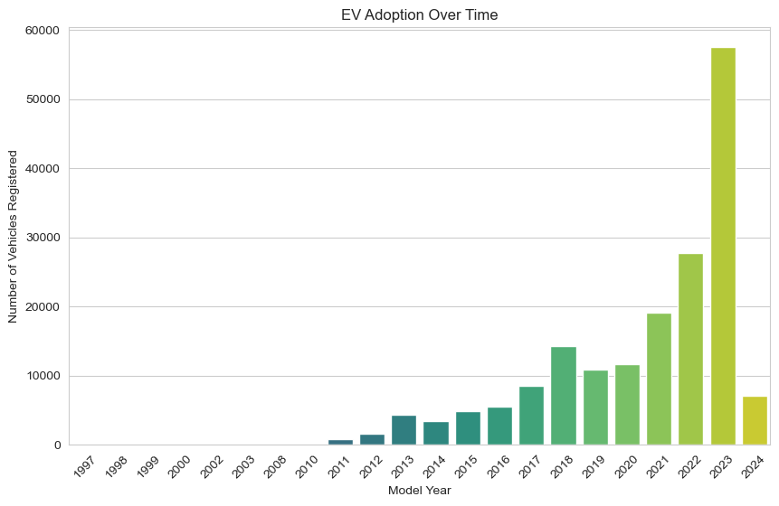

```python
plt.figure(figsize=(10,6))
sns.barplot(x = ev_adoption_by_year.index , y = ev_adoption_by_year.values , palette = 'viridis')
plt.title('EV Adoption Over Time')
plt.xlabel('Model Year')
plt.ylabel('Number of Vehicles Registered')
plt.xticks(rotation=45)
plt.show()
```

**From the above Bar chart, it's clear that EV Adoption has been increasing over time, especially noting a significant upward trend starting around 2016. The number of vehicles registered grows mostly up untill that point and than begins to rise more rapidly from 2017 onwards.**

**The year 2023 shows a particularly sharp increase in the number of registered EV's, indicating a peak in EV adoption.**

### Geographical Distribution of EV :

### Understand in which County and City, the EV's are most commonly registered.

```python
# geographical distribution at County level.

ev_county_distribution = ev_data['County'].value_counts()
ev_county_distribution
```

```
King            92740
Snohomish       21001
Pierce          13782
Clark           10409
Thurston         6428
Kitsap           5840
Spokane          4586
Whatcom          4253
Benton           2147
Skagit           1910
Island           1882
Clallam          1058
Chelan           1047
Yakima            995
Jefferson         974
San Juan          942
Cowlitz           897
Mason             823
Lewis             739
Grays Harbor      625
Kittitas          623
Franklin          585
Grant             561
Walla Walla       437
Douglas           364
Whitman           334
Klickitat         284
Okanogan          263
Stevens           219
Pacific           198
Skamania          192
Asotin             73
Wahkiakum          60
Pend Oreille       55
Lincoln            49
Adams              48
Ferry              31
Columbia           16
Garfield            3
Name: County, dtype: int64
```

### Top 3 counties based on EV registration.

```python
# Selecting the Top 3 counties based on EV registration

top_counties = ev_county_distribution.head(3).index
top_counties
```

```
Index(['King', 'Snohomish', 'Pierce'], dtype='object')
```

**'King', 'Snohomish', 'Pierce' are Top 3 counties based on highest number of EV registration.**

```python
# filtering the dataset for these top counties

top_counties_data = ev_data[ev_data['County'].isin(top_counties)]
top_counties_data
```

|  | VIN (1-10) | County | City | State | Postal Code | Model Year | Make | Model | Electric Vehicle Type | Clean Alternative Fuel Vehicle (CAFV) Eligibility | Electric Range | Base MSRP | Legislative District | DOL Vehicle ID | Vehicle Location | Electric Utility | 2020 Census Tract |
| --- | --- | --- | --- | --- | --- | --- | --- | --- | --- | --- | --- | --- | --- | --- | --- | --- | --- |
| 0 | 5YJYGDEE1L | King | Seattle | WA | 98122.0 | 2020 | TESLA | MODEL Y | Battery Electric Vehicle (BEV) | Clean Alternative Fuel Vehicle Eligible | 291 | 0 | 37.0 | 125701579 | POINT (-122.30839 47.610365) | CITY OF SEATTLE - (WA)\|CITY OF TACOMA - (WA) | 5.303301e+10 |
| 1 | 7SAYGDEE9P | Snohomish | Bothell | WA | 98021.0 | 2023 | TESLA | MODEL Y | Battery Electric Vehicle (BEV) | Eligibility unknown as battery range has not b... | 0 | 0 | 1.0 | 244285107 | POINT (-122.179458 47.802589) | PUGET SOUND ENERGY INC | 5.306105e+10 |
| 2 | 5YJSA1E4XK | King | Seattle | WA | 98109.0 | 2019 | TESLA | MODEL S | Battery Electric Vehicle (BEV) | Clean Alternative Fuel Vehicle Eligible | 270 | 0 | 36.0 | 156773144 | POINT (-122.34848 47.632405) | CITY OF SEATTLE - (WA)\|CITY OF TACOMA - (WA) | 5.303301e+10 |
| 3 | 5YJSA1E27G | King | Issaquah | WA | 98027.0 | 2016 | TESLA | MODEL S | Battery Electric Vehicle (BEV) | Clean Alternative Fuel Vehicle Eligible | 210 | 0 | 5.0 | 165103011 | POINT (-122.03646 47.534065) | PUGET SOUND ENERGY INC\|\|CITY OF TACOMA - (WA) | 5.303303e+10 |
| 7 | KNAGV4LD9J | Snohomish | Bothell | WA | 98012.0 | 2018 | KIA | OPTIMA | Plug-in Hybrid Electric Vehicle (PHEV) | Not eligible due to low battery range | 29 | 0 | 1.0 | 290605598 | POINT (-122.1873 47.820245) | PUGET SOUND ENERGY INC | 5.306105e+10 |
| ... | ... | ... | ... | ... | ... | ... | ... | ... | ... | ... | ... | ... | ... | ... | ... | ... | ... |
| 177858 | 5YJ3E1EB8N | Snohomish | Snohomish | WA | 98296.0 | 2022 | TESLA | MODEL 3 | Battery Electric Vehicle (BEV) | Eligibility unknown as battery range has not b... | 0 | 0 | 1.0 | 213520422 | POINT (-122.15134 47.8851158) | PUGET SOUND ENERGY INC | 5.306105e+10 |
| 177859 | 1N4BZ1DV7M | King | Redmond | WA | 98053.0 | 2021 | NISSAN | LEAF | Battery Electric Vehicle (BEV) | Eligibility unknown as battery range has not b... | 0 | 0 | 45.0 | 172798951 | POINT (-122.0222799 47.6958998) | PUGET SOUND ENERGY INC\|\|CITY OF TACOMA - (WA) | 5.303303e+10 |
| 177861 | 7SAYGDEE3N | Pierce | Bonney Lake | WA | 98391.0 | 2022 | TESLA | MODEL Y | Battery Electric Vehicle (BEV) | Eligibility unknown as battery range has not b... | 0 | 0 | 31.0 | 195224452 | POINT (-122.183805 47.18062) | PUGET SOUND ENERGY INC\|\|CITY OF TACOMA - (WA) | 5.305307e+10 |
| 177864 | WVGKMPE27M | King | Black Diamond | WA | 98010.0 | 2021 | VOLKSWAGEN | ID.4 | Battery Electric Vehicle (BEV) | Eligibility unknown as battery range has not b... | 0 | 0 | 5.0 | 182448801 | POINT (-122.00451 47.312185) | PUGET SOUND ENERGY INC\|\|CITY OF TACOMA - (WA) | 5.303303e+10 |
| 177865 | 5YJ3E1EA8M | Pierce | Tacoma | WA | 98422.0 | 2021 | TESLA | MODEL 3 | Battery Electric Vehicle (BEV) | Eligibility unknown as battery range has not b... | 0 | 0 | 27.0 | 211464683 | POINT (-122.38578 47.28971) | BONNEVILLE POWER ADMINISTRATION\|\|CITY OF TACOM... | 5.305394e+10 |

127523 rows × 17 columns

### Analyzing the distribution of EVs within the cities of these top counties.

```python
ev_city_distribution_top_counties = top_counties_data.groupby(['County','City']).size().sort_values(ascending=False).reset_index(name='Number of Vehicles')
ev_city_distribution_top_counties
```

|  | County | City | Number of Vehicles |
| --- | --- | --- | --- |
| 0 | King | Seattle | 29447 |
| 1 | King | Bellevue | 8930 |
| 2 | King | Redmond | 6478 |
| 3 | King | Kirkland | 5362 |
| 4 | King | Sammamish | 5280 |
| ... | ... | ... | ... |
| 108 | Snohomish | Alderwood Manor | 1 |
| 109 | Snohomish | Startup | 1 |
| 110 | King | Gold Bar | 1 |
| 111 | Pierce | Kapowsin | 1 |
| 112 | Pierce | Prairie Ridge | 1 |

113 rows × 3 columns

### Visualize Top 10 cities across these counties.

```python
top_cities = ev_city_distribution_top_counties.head(10)
top_cities
```

|  | County | City | Number of Vehicles |
| --- | --- | --- | --- |
| 0 | King | Seattle | 29447 |
| 1 | King | Bellevue | 8930 |
| 2 | King | Redmond | 6478 |
| 3 | King | Kirkland | 5362 |
| 4 | King | Sammamish | 5280 |
| 5 | King | Renton | 4980 |
| 6 | Snohomish | Bothell | 4663 |
| 7 | Pierce | Tacoma | 3722 |
| 8 | King | Tukwila | 2927 |
| 9 | King | Kent | 2782 |

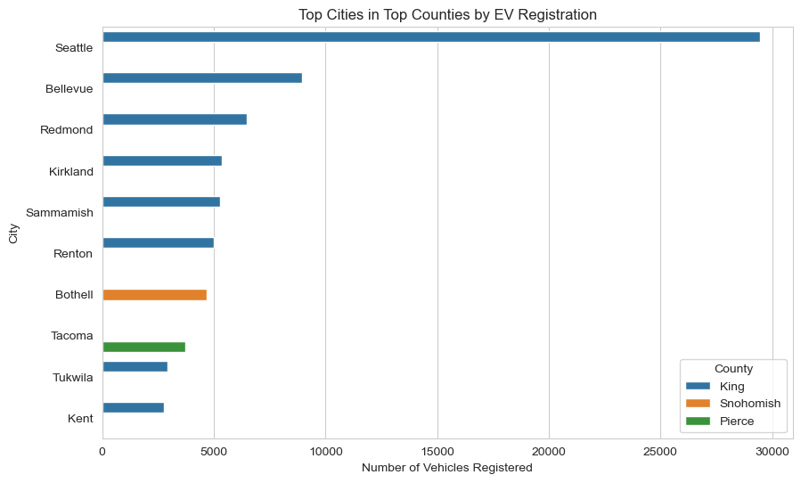

```python
plt.figure(figsize=(10,6))
sns.barplot(x = 'Number of Vehicles' , y = 'City' , hue = 'County' , data = top_cities)
plt.title('Top Cities in Top Counties by EV Registration')
plt.xlabel('Number of Vehicles Registered')
plt.ylabel('City')
plt.show()
```

**The above graph compares the number of electric vehicles registered in various cities within three counties: King, Snohomish, and Pierce. The horizontal bars represent cities, and their length corresponds to the number of vehicles registered, colour-coded by county.**

**- Seattle, which is in King County, has the highest number of EV registrations by a significant margin, far outpacing the other cities listed.**

**- Bellevue and Redmond, also in King County, follow Seattle with the next highest registrations, though these are considerably less than Seattle’s.**

**- Cities in King County, such as Kirkland, Sammamish and Renton, show moderate EV registrations.**

**- Bothell, which is in Snohomish County, show moderate EV registrations.**

**The majority of cities shown are from King County, seems to dominate EV registrations among the three counties.**

### EV Types :

### Analyzing the dataset by Electric Vehicle Type (BEV and PHEV).

```python
ev_type_distribution = ev_data['Electric Vehicle Type'].value_counts()
ev_type_distribution
```

```
Battery Electric Vehicle (BEV)            138947
Plug-in Hybrid Electric Vehicle (PHEV)     38526
Name: Electric Vehicle Type, dtype: int64
```

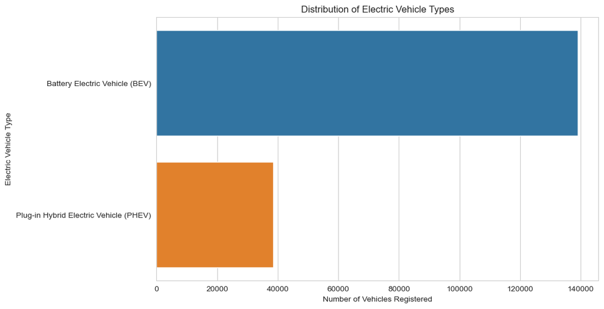

```python
plt.figure(figsize=(10,6))
sns.barplot(x = ev_type_distribution.values , y = ev_type_distribution.index)
plt.title('Distribution of Electric Vehicle Types')
plt.xlabel('Number of Vehicles Registered')
plt.ylabel('Electric Vehicle Type')
plt.show()
```

**The above graph shows that BEVs are more popular or preferred over PHEVs among the electric vehicles registered in the United States.**

### Make and Model Popularity :

### Identify the most popular makes and models among the registered EVs.

### Analyzing the popularity of EV manufacturers

```python
# Top 10 EV Manufacturers

ev_make_distribution = ev_data['Make'].value_counts().head(10)
ev_make_distribution
```

```
TESLA         79471
NISSAN        13984
CHEVROLET     13651
FORD           9177
BMW            7556
KIA            7423
TOYOTA         6254
VOLKSWAGEN     4993
JEEP           4468
HYUNDAI        4398
Name: Make, dtype: int64
```

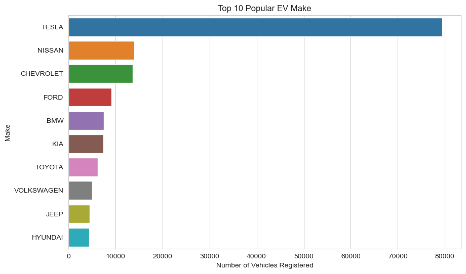

```python
plt.figure(figsize=(10,6))
sns.barplot(x = ev_make_distribution.values , y = ev_make_distribution.index)
plt.title('Top 10 Popular EV Make')
plt.xlabel('Number of Vehicles Registered')
plt.ylabel('Make')
plt.show()
```

**Above chart shows that:**

**- TESLA leads by a substantial margin with the highest number of vehicles registered.**

**- NISSAN is the second most popular manufacturer, followed by CHEVROLET, though both have significantly fewer registrations than TESLA.**

**- FORD, BMW, KIA, TOYOTA, VOLKSWAGEN, JEEP, and HYUNDAI follow in decreasing order of the number of registered vehicles.**

### Top 3 Make based on Number of Vehicles registered.

```python
top_3_makes = ev_make_distribution.head(3).index
top_3_makes
```

```
Index(['TESLA', 'NISSAN', 'CHEVROLET'], dtype='object')
```

### Filtering the dataset for these top 3 manufacturers

```python
top_makes_data = ev_data[ev_data['Make'].isin(top_3_makes)]
top_makes_data
```

|  | VIN (1-10) | County | City | State | Postal Code | Model Year | Make | Model | Electric Vehicle Type | Clean Alternative Fuel Vehicle (CAFV) Eligibility | Electric Range | Base MSRP | Legislative District | DOL Vehicle ID | Vehicle Location | Electric Utility | 2020 Census Tract |
| --- | --- | --- | --- | --- | --- | --- | --- | --- | --- | --- | --- | --- | --- | --- | --- | --- | --- |
| 0 | 5YJYGDEE1L | King | Seattle | WA | 98122.0 | 2020 | TESLA | MODEL Y | Battery Electric Vehicle (BEV) | Clean Alternative Fuel Vehicle Eligible | 291 | 0 | 37.0 | 125701579 | POINT (-122.30839 47.610365) | CITY OF SEATTLE - (WA)\|CITY OF TACOMA - (WA) | 5.303301e+10 |
| 1 | 7SAYGDEE9P | Snohomish | Bothell | WA | 98021.0 | 2023 | TESLA | MODEL Y | Battery Electric Vehicle (BEV) | Eligibility unknown as battery range has not b... | 0 | 0 | 1.0 | 244285107 | POINT (-122.179458 47.802589) | PUGET SOUND ENERGY INC | 5.306105e+10 |
| 2 | 5YJSA1E4XK | King | Seattle | WA | 98109.0 | 2019 | TESLA | MODEL S | Battery Electric Vehicle (BEV) | Clean Alternative Fuel Vehicle Eligible | 270 | 0 | 36.0 | 156773144 | POINT (-122.34848 47.632405) | CITY OF SEATTLE - (WA)\|CITY OF TACOMA - (WA) | 5.303301e+10 |
| 3 | 5YJSA1E27G | King | Issaquah | WA | 98027.0 | 2016 | TESLA | MODEL S | Battery Electric Vehicle (BEV) | Clean Alternative Fuel Vehicle Eligible | 210 | 0 | 5.0 | 165103011 | POINT (-122.03646 47.534065) | PUGET SOUND ENERGY INC\|\|CITY OF TACOMA - (WA) | 5.303303e+10 |
| 4 | 5YJYGDEE5M | Kitsap | Suquamish | WA | 98392.0 | 2021 | TESLA | MODEL Y | Battery Electric Vehicle (BEV) | Eligibility unknown as battery range has not b... | 0 | 0 | 23.0 | 205138552 | POINT (-122.55717 47.733415) | PUGET SOUND ENERGY INC | 5.303594e+10 |
| ... | ... | ... | ... | ... | ... | ... | ... | ... | ... | ... | ... | ... | ... | ... | ... | ... | ... |
| 177859 | 1N4BZ1DV7M | King | Redmond | WA | 98053.0 | 2021 | NISSAN | LEAF | Battery Electric Vehicle (BEV) | Eligibility unknown as battery range has not b... | 0 | 0 | 45.0 | 172798951 | POINT (-122.0222799 47.6958998) | PUGET SOUND ENERGY INC\|\|CITY OF TACOMA - (WA) | 5.303303e+10 |
| 177860 | 1G1FX6S00J | Clallam | Sequim | WA | 98382.0 | 2018 | CHEVROLET | BOLT EV | Battery Electric Vehicle (BEV) | Clean Alternative Fuel Vehicle Eligible | 238 | 0 | 24.0 | 347972607 | POINT (-123.105015 48.08125) | BONNEVILLE POWER ADMINISTRATION\|\|PUD NO 1 OF C... | 5.300900e+10 |
| 177861 | 7SAYGDEE3N | Pierce | Bonney Lake | WA | 98391.0 | 2022 | TESLA | MODEL Y | Battery Electric Vehicle (BEV) | Eligibility unknown as battery range has not b... | 0 | 0 | 31.0 | 195224452 | POINT (-122.183805 47.18062) | PUGET SOUND ENERGY INC\|\|CITY OF TACOMA - (WA) | 5.305307e+10 |
| 177863 | 5YJYGDEE6M | Grant | Quincy | WA | 98848.0 | 2021 | TESLA | MODEL Y | Battery Electric Vehicle (BEV) | Eligibility unknown as battery range has not b... | 0 | 0 | 13.0 | 168797219 | POINT (-119.8493873 47.2339933) | PUD NO 2 OF GRANT COUNTY | 5.302501e+10 |
| 177865 | 5YJ3E1EA8M | Pierce | Tacoma | WA | 98422.0 | 2021 | TESLA | MODEL 3 | Battery Electric Vehicle (BEV) | Eligibility unknown as battery range has not b... | 0 | 0 | 27.0 | 211464683 | POINT (-122.38578 47.28971) | BONNEVILLE POWER ADMINISTRATION\|\|CITY OF TACOM... | 5.305394e+10 |

107106 rows × 17 columns

### Analyzing the popularity of EV models within these top manufacturers

```python
ev_model_distribution_top_makes = top_makes_data.groupby(['Make','Model']).size().sort_values(ascending=False).reset_index(name='Number of Vehicles')
ev_model_distribution_top_makes
```

|  | Make | Model | Number of Vehicles |
| --- | --- | --- | --- |
| 0 | TESLA | MODEL Y | 35921 |
| 1 | TESLA | MODEL 3 | 30009 |
| 2 | NISSAN | LEAF | 13352 |
| 3 | TESLA | MODEL S | 7711 |
| 4 | CHEVROLET | BOLT EV | 6811 |
| 5 | TESLA | MODEL X | 5784 |
| 6 | CHEVROLET | VOLT | 4782 |
| 7 | CHEVROLET | BOLT EUV | 1770 |
| 8 | NISSAN | ARIYA | 632 |
| 9 | CHEVROLET | SPARK | 240 |
| 10 | TESLA | ROADSTER | 46 |
| 11 | CHEVROLET | SILVERADO EV | 33 |
| 12 | CHEVROLET | BLAZER EV | 14 |
| 13 | CHEVROLET | S-10 PICKUP | 1 |

### Visualizing Top 10 models across these top manufacturers

```python
top_models = ev_model_distribution_top_makes.head(10)
top_models
```

|  | Make | Model | Number of Vehicles |
| --- | --- | --- | --- |
| 0 | TESLA | MODEL Y | 35921 |
| 1 | TESLA | MODEL 3 | 30009 |
| 2 | NISSAN | LEAF | 13352 |
| 3 | TESLA | MODEL S | 7711 |
| 4 | CHEVROLET | BOLT EV | 6811 |
| 5 | TESLA | MODEL X | 5784 |
| 6 | CHEVROLET | VOLT | 4782 |
| 7 | CHEVROLET | BOLT EUV | 1770 |
| 8 | NISSAN | ARIYA | 632 |
| 9 | CHEVROLET | SPARK | 240 |

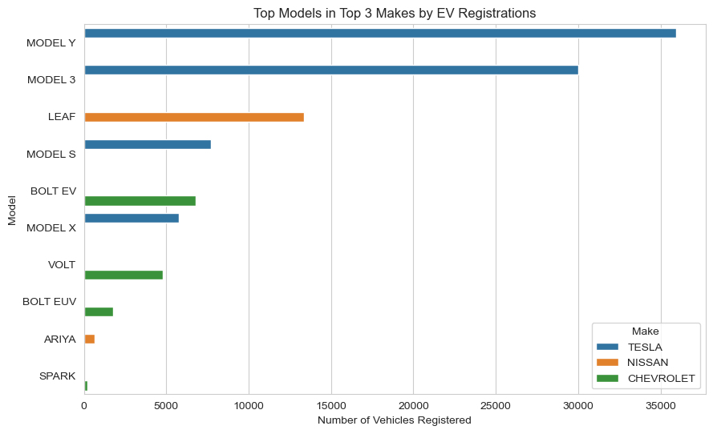

```python
plt.figure(figsize=(10,6))
sns.barplot(x = 'Number of Vehicles' , y = 'Model' , hue = 'Make' , data = top_models)
plt.title('Top Models in Top 3 Makes by EV Registrations')
plt.xlabel('Number of Vehicles Registered')
plt.ylabel('Model')
plt.show()
```

**Above graph shows the distribution of electric vehicle registrations among different models from the top three manufacturers: TESLA, NISSAN, and CHEVROLET.**

**- TESLA’s MODEL Y and MODEL 3 are the most registered vehicles, with MODEL Y having the highest number of registrations.**

**- NISSAN’s LEAF is the third most registered model**

**- TESLA’s MODEL S and MODEL X also have a significant number of registrations.**

**- CHEVROLET’s BOLT EV and VOLT are the next in the ranking with considerable registrations, followed by BOLT EUV.**

**- NISSAN’s ARIYA and CHEVROLET’s SPARK have the least number of registrations among the models shown.**

### Electric range Analysis :

### Electric range indicates how far an EV can travel on a single charge.

### Analyzing the distribution of Electric Range

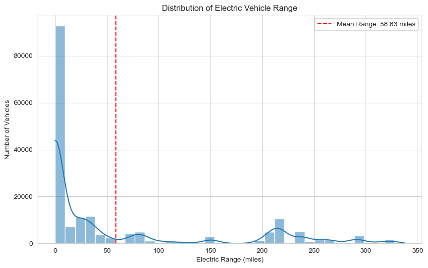

```python
plt.figure(figsize=(10,6))
sns.histplot(ev_data['Electric Range'] , bins = 35 , kde = True)
plt.title('Distribution of Electric Vehicle Range')
plt.xlabel('Electric Range (miles)')
plt.ylabel('Number of Vehicles')
plt.axvline(ev_data['Electric Range'].mean() , color = 'Red' , linestyle = '--' , label = f'Mean Range: {ev_data["Electric Range"].mean():.2f} miles')
plt.legend()
plt.show()
```

**The above graph shows mean Electric Range.**

**The distribution is skewed to the right, with a long tail extending towards higher ranges, although the number of vehicles with higher ranges is much less frequent.**

**Despite the presence of electric vehicles with ranges that extend up to around 350 miles, the majority of the vehicles have a range below the mean.**

### Calculating the Average Electric Range by Model Year.

```python
average_range_by_year = ev_data.groupby('Model Year')['Electric Range'].mean().reset_index()
average_range_by_year
```

|  | Model Year | Electric Range |
| --- | --- | --- |
| 0 | 1997 | 39.000000 |
| 1 | 1998 | 58.000000 |
| 2 | 1999 | 74.000000 |
| 3 | 2000 | 58.000000 |
| 4 | 2002 | 95.000000 |
| 5 | 2003 | 95.000000 |
| 6 | 2008 | 220.000000 |
| 7 | 2010 | 226.086957 |
| 8 | 2011 | 70.891613 |
| 9 | 2012 | 61.172243 |
| 10 | 2013 | 79.822232 |
| 11 | 2014 | 80.798341 |
| 12 | 2015 | 98.254869 |
| 13 | 2016 | 101.197111 |
| 14 | 2017 | 114.162292 |
| 15 | 2018 | 156.165967 |
| 16 | 2019 | 176.918904 |
| 17 | 2020 | 238.748978 |
| 18 | 2021 | 11.402665 |
| 19 | 2022 | 4.518045 |
| 20 | 2023 | 3.729168 |
| 21 | 2024 | 16.791431 |

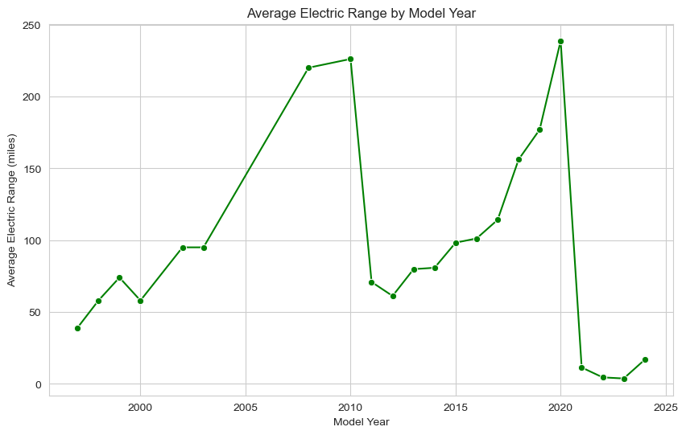

```python
plt.figure(figsize=(10,6))
sns.lineplot(x = 'Model Year' , y = 'Electric Range' , data = average_range_by_year , marker = 'o' , color = 'Green')
plt.title('Average Electric Range by Model Year')
plt.xlabel('Model Year')
plt.ylabel('Average Electric Range (miles)')
plt.show()
```

**The above graph shows the progression of the average electric range of vehicles from around the year 2000 to 2024.**

**- There is a noticeable peak around the year 2020 when the average range reaches its highest point.**

**- Following 2020, there’s a significant drop in the average range, which could indicate that data for the following years might be incomplete or reflect the introduction of several lower-range models.**

**- After the sharp decline, there is a slight recovery in the average range in the most recent year shown on the graph.**

### Average Electric Ranges among the top Manufacturers and Models.

```python
average_range_by_model = top_makes_data.groupby(['Make','Model'])['Electric Range'].mean().sort_values(ascending=False).reset_index()
average_range_by_model
```

|  | Make | Model | Electric Range |
| --- | --- | --- | --- |
| 0 | TESLA | ROADSTER | 234.673913 |
| 1 | TESLA | MODEL S | 176.794449 |
| 2 | CHEVROLET | BOLT EV | 154.857143 |
| 3 | TESLA | MODEL X | 137.192600 |
| 4 | TESLA | MODEL 3 | 109.463028 |
| 5 | NISSAN | LEAF | 84.148742 |
| 6 | CHEVROLET | SPARK | 82.000000 |
| 7 | CHEVROLET | VOLT | 45.365119 |
| 8 | CHEVROLET | S-10 PICKUP | 39.000000 |
| 9 | TESLA | MODEL Y | 19.191531 |
| 10 | CHEVROLET | BLAZER EV | 0.000000 |
| 11 | CHEVROLET | BOLT EUV | 0.000000 |
| 12 | CHEVROLET | SILVERADO EV | 0.000000 |
| 13 | NISSAN | ARIYA | 0.000000 |

### Top 10 Models with the highest Average Electric Range

```python
top_range_models = average_range_by_model.head(10)
top_range_models
```

|  | Make | Model | Electric Range |
| --- | --- | --- | --- |
| 0 | TESLA | ROADSTER | 234.673913 |
| 1 | TESLA | MODEL S | 176.794449 |
| 2 | CHEVROLET | BOLT EV | 154.857143 |
| 3 | TESLA | MODEL X | 137.192600 |
| 4 | TESLA | MODEL 3 | 109.463028 |
| 5 | NISSAN | LEAF | 84.148742 |
| 6 | CHEVROLET | SPARK | 82.000000 |
| 7 | CHEVROLET | VOLT | 45.365119 |
| 8 | CHEVROLET | S-10 PICKUP | 39.000000 |
| 9 | TESLA | MODEL Y | 19.191531 |

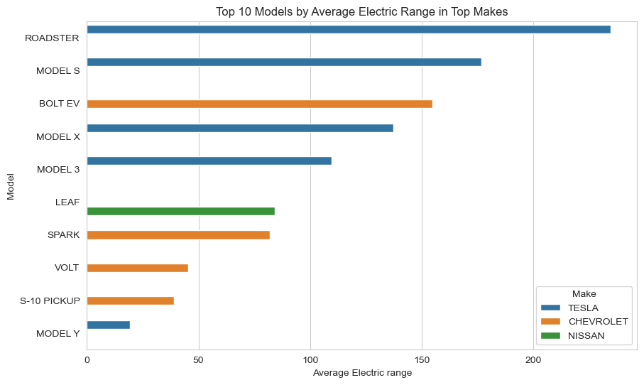

```python
plt.figure(figsize=(10,6))
sns.barplot(x = 'Electric Range' , y = 'Model' , hue = 'Make' , data = top_range_models)
plt.title('Top 10 Models by Average Electric Range in Top Makes')
plt.xlabel('Average Electric range')
plt.ylabel('Model')
plt.show()
```

**The TESLA ROADSTER has the highest average electric range among the models listed. TESLA’s models (ROADSTER, MODEL S, MODEL X, and MODEL 3) occupy the majority of the top positions, indicating that on average, TESLA’s vehicles have higher electric ranges.**

**The CHEVROLET BOLT EV is an outlier among the CHEVROLET models, having a substantially higher range than the VOLT and S-10 PICKUP from the same maker.**

**NISSAN’s LEAF and CHEVROLET’s SPARK are in the lower half of the chart, suggesting more modest average ranges.**

### Estimated Growth in Market Size :

### Estimated Market Size Analysis of Electric Vehicles in the United States

### Calculate the number of EVs registered each year

```python
ev_registration_counts = ev_data['Model Year'].value_counts().sort_index()
ev_registration_counts
```

```
1997        1
1998        1
1999        5
2000        7
2002        2
2003        1
2008       19
2010       23
2011      775
2012     1614
2013     4399
2014     3496
2015     4826
2016     5469
2017     8534
2018    14286
2019    10913
2020    11740
2021    19063
2022    27708
2023    57519
2024     7072
Name: Model Year, dtype: int64
```

**The dataset provides the number of electric vehicles registered each year from 1997 through 2024. However, the data for 2024 is incomplete as it only contains the data till March.**

**- In 2021, there were 19,063 EVs registered.**

**- In 2022, the number increased to 27708 EVs.**

**- In 2023, a significant jump to 57,519 EVs was observed.**

**- For 2024, currently, 7,072 EVs are registered, which suggests partial data.**

**- To forecast the total number of EVs expected to be registered in 2024, we can use a growth rate based approach from previous complete years.**

```python
# Import required libraries

from scipy.optimize import curve_fit
import numpy as np
```

### Filter the dataset to include years with complete data, assuming 2023 is the last complete year

```python
filtered_years = ev_registration_counts[ev_registration_counts.index <= 2023]
filtered_years
```

```
1997        1
1998        1
1999        5
2000        7
2002        2
2003        1
2008       19
2010       23
2011      775
2012     1614
2013     4399
2014     3496
2015     4826
2016     5469
2017     8534
2018    14286
2019    10913
2020    11740
2021    19063
2022    27708
2023    57519
Name: Model Year, dtype: int64
```

### Define a function for exponential growth to fit the data

```python
def exp_growth(x, a, b):
    return a * np.exp(b * x)
```

### Prepare the data for curve fitting

```python
x_data = filtered_years.index - filtered_years.index.min()
x_data
```

```
Int64Index([0, 1, 2, 3, 5, 6, 11, 13, 14, 15, 16, 17, 18, 19, 20, 21, 22, 23,
            24, 25, 26],
           dtype='int64')
```

```python
y_data = filtered_years.values
y_data
```

```
array([    1,     1,     5,     7,     2,     1,    19,    23,   775,
        1614,  4399,  3496,  4826,  5469,  8534, 14286, 10913, 11740,
       19063, 27708, 57519], dtype=int64)
```

### Fit the data to the exponential growth function

```python
params, covariance = curve_fit(exp_growth, x_data, y_data)
```

```python
params
```

```
array([1.1008126 , 0.41415395])
```

```python
covariance
```

```
array([[ 1.28914317, -0.04634423],
       [-0.04634423,  0.00166966]])
```

### Use the fitted function to forecast the number of EVs for 2024 and the next five years

```python
forecast_years = np.arange(2024, 2024 + 6) - filtered_years.index.min()
forecast_years
```

```
array([27, 28, 29, 30, 31, 32])
```

```python
forecast_values = exp_growth(forecast_years, *params)
forecast_values
```

```
array([ 79079.20808939, 119653.96274429, 181047.22020266, 273940.74706209,
       414497.01805382, 627171.31284077])
```

### Create a dictionary to display the forecasted values for easier interpretation

```python
forecasted_EVs = dict(zip(forecast_years + filtered_years.index.min() , forecast_values))
forecasted_EVs
```

```
{2024: 79079.20808938889,
 2025: 119653.96274428742,
 2026: 181047.22020265696,
 2027: 273940.74706208805,
 2028: 414497.01805382164,
 2029: 627171.3128407666}
```

### Prepare data for plotting

```python
years = np.arange(filtered_years.index.min(), 2029 + 1)
years
```

```
array([1997, 1998, 1999, 2000, 2001, 2002, 2003, 2004, 2005, 2006, 2007,
       2008, 2009, 2010, 2011, 2012, 2013, 2014, 2015, 2016, 2017, 2018,
       2019, 2020, 2021, 2022, 2023, 2024, 2025, 2026, 2027, 2028, 2029],
      dtype=int64)
```

```python
actual_years = filtered_years.index
actual_years
```

```
Int64Index([1997, 1998, 1999, 2000, 2002, 2003, 2008, 2010, 2011, 2012, 2013,
            2014, 2015, 2016, 2017, 2018, 2019, 2020, 2021, 2022, 2023],
           dtype='int64')
```

```python
forecast_years_full = np.arange(2024, 2029 + 1)
forecast_years_full
```

```
array([2024, 2025, 2026, 2027, 2028, 2029])
```

### Visualize Actual and Forecasted values

```python
actual_values = filtered_years.values
actual_values
```

```
array([    1,     1,     5,     7,     2,     1,    19,    23,   775,
        1614,  4399,  3496,  4826,  5469,  8534, 14286, 10913, 11740,
       19063, 27708, 57519], dtype=int64)
```

```python
forecasted_values_full = [forecasted_EVs[years] for years in forecast_years_full]
forecasted_values_full
```

```
[79079.20808938889,
 119653.96274428742,
 181047.22020265696,
 273940.74706208805,
 414497.01805382164,
 627171.3128407666]
```

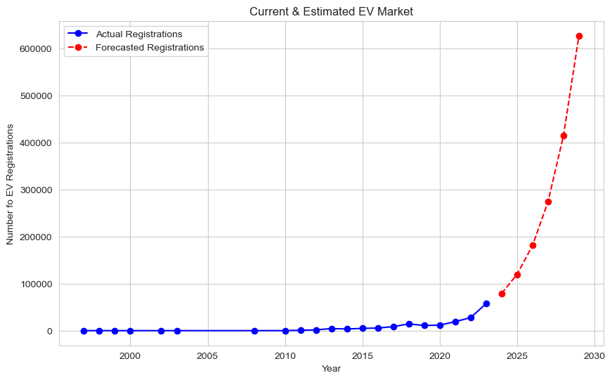

```python
plt.figure(figsize=(10,6))
plt.plot(actual_years , actual_values , 'bo-' , label='Actual Registrations')
plt.plot(forecast_years_full , forecasted_values_full , 'ro--' , label='Forecasted Registrations')

plt.title('Current & Estimated EV Market')
plt.xlabel('Year')
plt.ylabel('Number fo EV Registrations')
plt.legend()
plt.show()
```

**From the above graph, we can see:**

**- The forecasted EV registrations predict an even more dramatic increase in the near future, with the number of registrations expected to rise sharply in the coming years.**

**The growing trend in actual EV registrations and the projected acceleration as per the forecast data, we can conclude that the EV market size is expected to expand considerably. The steep increase in forecasted registrations suggests that consumer adoption of EVs is on the rise, and this trend is likely to continue. Overall, the data point towards a promising future for the EV industry, indicating a significant shift in consumer preferences and a potential increase in related investment and business opportunities.**

### Summary :

### From our market size analysis of electric vehicles, we found a promising future for the EV industry, indicating a significant shift in consumer preferences and a potential increase in related investment and business opportunities.